# Week 10 Practice

BDS

July 5, 2018

```r
library(poLCA)
```

```r
readLines("C:/Users/berry2006/Documents/projects/courses/bds/exerciseData/week10.csv")[1:10]
```

```
##  [1] ",,,,,,,,,,,,,,,"
##  [2] ",,,,,,,,,,,,,,,"
##  [3] ",,,,,,,,,,,,,,,"
##  [4] "\"id\",\"team\",\"manager\",\"jobTasksSDSA\",\"jobBalanceSDSA\",\"jobPaySDSA\",\"jobRecognitionSDSA\",\"jobAdvancementSDSA\",\"jobCoworkersSDSA\",\"jobManagementSDSA\",\"salary\",\"tenure\",\"age\",\"genderFM\",\"degreeBMP\",\"citizenNY\""
##  [5] "\"W472V\",\"Ethics\",\"X8022Z\",7,3,7,7,7,5,4,126460,6,30,2,3,2"
##  [6] "\"S227N\",\"DSI\",\"V8472W\",1,6,3,2,2,7,7,47749,1,38,1,1,1"
##  [7] "\"N333E\",\"Finance\",\"X7645X\",7,7,7,7,7,7,,80828,6,24,2,3,1"
##  [8] "\"K503P\",\"Finance\",\"Y4468Y\",2,2,4,3,4,3,3,52852,6,35,1,1,2"
##  [9] "\"J845U\",\"R&D\",\"X8066X\",6,3,7,7,7,4,4,98429,10,46,2,3,2"
## [10] "\"O834K\",\"Finance\",\"Z7298V\",3,3,4,4,4,4,3,45397,1,50,1,1,2"
```

Blank lines…cute!

Fortunately, this is always an easy problem to fix:

```r
week10 = read.csv("C:/Users/berry2006/Documents/projects/courses/bds/exerciseData/week10.csv", skip = 3)
```

There are many ways to conduct some latent class analysis in R, but I tend to like poLCA the most. It grants us the ability to perform latent class analysis on polytomous data, instead of just dichotomous data.

We should see what is in our data:

```r
summary(week10)
```

```
##        id            team        manager     jobTasksSDSA
##  A103R  :   1   DSI    : 64   Y9641W : 99   Min.   :1.000
##  A105D  :   1   Ethics :199   X7645X : 95   1st Qu.:2.000
##  A105O  :   1   Finance:441   Y3553W : 95   Median :4.000
##  A126C  :   1   Health :239   Y4468Y : 91   Mean   :4.004
##  A129A  :   1   R&D    :441   X8066X : 88   3rd Qu.:6.000
##  A163W  :   1                 Z2464Y : 88   Max.   :7.000
##  (Other):1378                 (Other):828
##  jobBalanceSDSA    jobPaySDSA    jobRecognitionSDSA jobAdvancementSDSA
##  Min.   :1.000   Min.   :1.000   Min.   :1.000      Min.   :1.00
##  1st Qu.:2.000   1st Qu.:4.000   1st Qu.:4.000      1st Qu.:4.00
##  Median :4.000   Median :6.000   Median :5.000      Median :5.00
##  Mean   :4.069   Mean   :5.178   Mean   :5.173      Mean   :5.21
##  3rd Qu.:6.000   3rd Qu.:7.000   3rd Qu.:7.000      3rd Qu.:7.00
##  Max.   :7.000   Max.   :7.000   Max.   :7.000      Max.   :7.00
##
##  jobCoworkersSDSA jobManagementSDSA     salary           tenure
##  Min.   :1.000    Min.   :0.000     Min.   : 45002   Min.   : 0.000
##  1st Qu.:4.000    1st Qu.:4.000     1st Qu.: 53555   1st Qu.: 2.000
##  Median :6.000    Median :5.000     Median : 64990   Median : 5.000
##  Mean   :5.259    Mean   :5.174     Mean   : 76578   Mean   : 4.952
##  3rd Qu.:7.000    3rd Qu.:7.000     3rd Qu.: 93051   3rd Qu.: 8.000
##  Max.   :7.000    Max.   :7.000     Max.   :171648   Max.   :10.000
##                   NA's   :212
##       age           genderFM       degreeBMP       citizenNY
##  Min.   :22.00   Min.   :1.000   Min.   :1.000   Min.   :1.000
##  1st Qu.:30.00   1st Qu.:1.000   1st Qu.:1.000   1st Qu.:2.000
##  Median :38.00   Median :2.000   Median :2.000   Median :2.000
##  Mean   :38.22   Mean   :1.505   Mean   :1.983   Mean   :1.795
##  3rd Qu.:47.00   3rd Qu.:2.000   3rd Qu.:3.000   3rd Qu.:2.000
##  Max.   :55.00   Max.   :2.000   Max.   :3.000   Max.   :2.000
##
```

We can try to fit a some latent classes to gender, degree, and citizen.

The interface for poLCA is a bit odd at first, but it makes sense as you move through it.

```r
lcaFormula = cbind(genderFM, degreeBMP, citizenNY) ~ 1

lca2Classes = poLCA(lcaFormula, week10, nclass = 2, maxiter = 5000)
```

```
## Conditional item response (column) probabilities,
##  by outcome variable, for each class (row)
##
## $genderFM
##            Pr(1)  Pr(2)
## class 1:  0.1945 0.8055
## class 2:  0.7426 0.2574
##
## $degreeBMP
##            Pr(1)  Pr(2)  Pr(3)
## class 1:  0.0878 0.1618 0.7504
## class 2:  0.5881 0.4018 0.0102
##
## $citizenNY
##            Pr(1)  Pr(2)
## class 1:  0.2088 0.7912
## class 2:  0.2022 0.7978
##
## Estimated class population shares
##  0.4519 0.5481
##
## Predicted class memberships (by modal posterior prob.)
##  0.4603 0.5397
##
## =========================================================
## Fit for 2 latent classes:
## =========================================================
## number of observations: 1384
## number of estimated parameters: 9
## residual degrees of freedom: 2
## maximum log-likelihood: -3043.681
##
## AIC(2): 6105.362
## BIC(2): 6152.456
## G^2(2): 0.2281196 (Likelihood ratio/deviance statistic)
## X^2(2): 0.2278258 (Chi-square goodness of fit)
##
## ALERT: iterations finished, MAXIMUM LIKELIHOOD NOT FOUND
##
```

While it takes just a minute to parse the following plot, it is a useful tool for gaining some understanding of what the latent class look like:

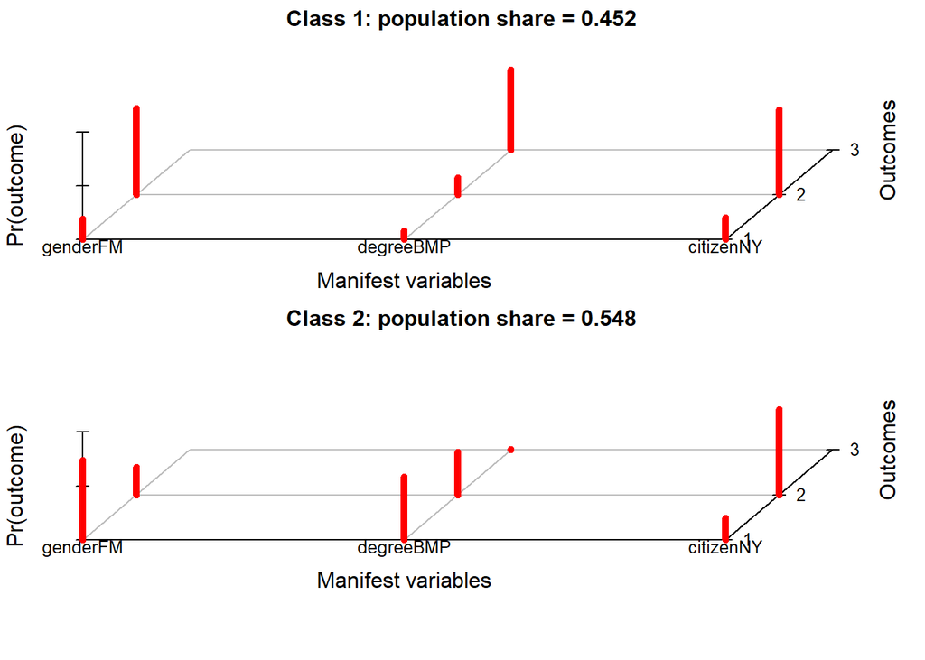

```r
plot(lca2Classes)
```

As with most things related to dimension reduction, we need to do some work to know how many divisions (classes, in this case) within our data we need to make.

```r
lca3Classes = poLCA(lcaFormula, week10, nclass = 3, maxiter = 5000)
```

```
## Conditional item response (column) probabilities,
##  by outcome variable, for each class (row)
##
## $genderFM
##            Pr(1)  Pr(2)
## class 1:  0.7755 0.2245
## class 2:  0.7780 0.2220
## class 3:  0.1490 0.8510
##
## $degreeBMP
##            Pr(1)  Pr(2)  Pr(3)
## class 1:  0.5542 0.3950 0.0508
## class 2:  0.5817 0.3456 0.0727
## class 3:  0.1202 0.1774 0.7024
##
## $citizenNY
##           Pr(1) Pr(2)
## class 1:  0.111 0.889
## class 2:  0.721 0.279
## class 3:  0.207 0.793
##
## Estimated class population shares
##  0.468 0.0839 0.4481
##
## Predicted class memberships (by modal posterior prob.)
##  0.4299 0.086 0.4841
##
## =========================================================
## Fit for 3 latent classes:
## =========================================================
## number of observations: 1384
## number of estimated parameters: 14
## residual degrees of freedom: -3
## maximum log-likelihood: -3043.568
##
## AIC(3): 6115.136
## BIC(3): 6188.394
## G^2(3): 0.00223547 (Likelihood ratio/deviance statistic)
## X^2(3): 0.002233934 (Chi-square goodness of fit)
##
## ALERT: iterations finished, MAXIMUM LIKELIHOOD NOT FOUND
##
## ALERT: negative degrees of freedom; respecify model
##
```

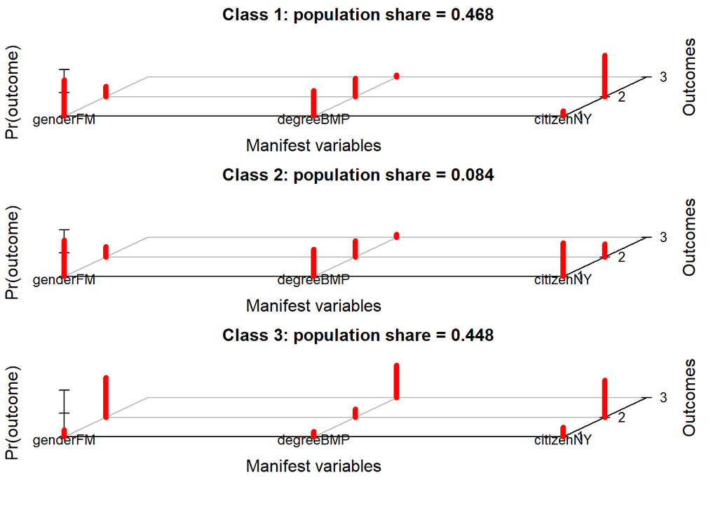

```r
plot(lca3Classes)
```

```r
lca4Classes = poLCA(lcaFormula, week10, nclass = 4, maxiter = 5000)
```

```
## Conditional item response (column) probabilities,
##  by outcome variable, for each class (row)
##
## $genderFM
##            Pr(1)  Pr(2)
## class 1:  0.0509 0.9491
## class 2:  0.1706 0.8294
## class 3:  0.5754 0.4246
## class 4:  0.8361 0.1639
##
## $degreeBMP
##            Pr(1)  Pr(2)  Pr(3)
## class 1:  0.0926 0.0798 0.8277
## class 2:  0.1548 0.1609 0.6843
## class 3:  0.3261 0.5031 0.1707
## class 4:  0.6446 0.3037 0.0517
##
## $citizenNY
##            Pr(1)  Pr(2)
## class 1:  0.1484 0.8516
## class 2:  0.3337 0.6663
## class 3:  0.1654 0.8346
## class 4:  0.2176 0.7824
##
## Estimated class population shares
##  0.2105 0.15 0.2918 0.3477
##
## Predicted class memberships (by modal posterior prob.)
##  0.2175 0.0723 0.4046 0.3056
##
## =========================================================
## Fit for 4 latent classes:
## =========================================================
## number of observations: 1384
## number of estimated parameters: 19
## residual degrees of freedom: -8
## maximum log-likelihood: -3043.567
##
## AIC(4): 6125.133
## BIC(4): 6224.555
## G^2(4): 1.820378e-08 (Likelihood ratio/deviance statistic)
## X^2(4): 1.8189e-08 (Chi-square goodness of fit)
##
## ALERT: negative degrees of freedom; respecify model
##
```

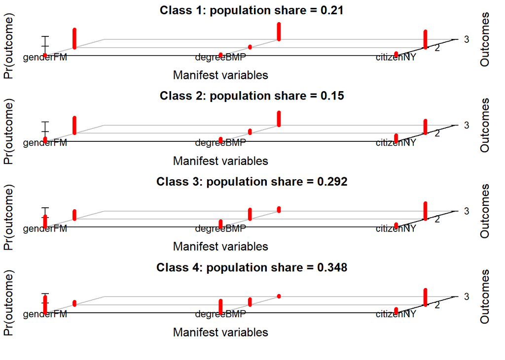

```r
plot(lca4Classes)
```

```r
lca5Classes = poLCA(lcaFormula, week10, nclass = 5, maxiter = 5000)
```

```
## Conditional item response (column) probabilities,
##  by outcome variable, for each class (row)
##
## $genderFM
##            Pr(1)  Pr(2)
## class 1:  0.9598 0.0402
## class 2:  0.6033 0.3967
## class 3:  0.2261 0.7739
## class 4:  0.2337 0.7663
## class 5:  0.0721 0.9279
##
## $degreeBMP
##            Pr(1)  Pr(2)  Pr(3)
## class 1:  0.5827 0.4120 0.0052
## class 2:  0.5258 0.2520 0.2222
## class 3:  0.1473 0.2905 0.5622
## class 4:  0.2801 0.2238 0.4962
## class 5:  0.1174 0.1610 0.7216
##
## $citizenNY
##            Pr(1)  Pr(2)
## class 1:  0.1718 0.8282
## class 2:  0.5680 0.4320
## class 3:  0.2094 0.7906
## class 4:  0.0712 0.9288
## class 5:  0.3137 0.6863
##
## Estimated class population shares
##  0.3541 0.081 0.153 0.2592 0.1527
##
## Predicted class memberships (by modal posterior prob.)
##  0.4249 0.039 0.0231 0.4559 0.0571
##
## =========================================================
## Fit for 5 latent classes:
## =========================================================
## number of observations: 1384
## number of estimated parameters: 24
## residual degrees of freedom: -13
## maximum log-likelihood: -3043.567
##
## AIC(5): 6135.133
## BIC(5): 6260.719
## G^2(5): 6.534545e-09 (Likelihood ratio/deviance statistic)
## X^2(5): 6.514826e-09 (Chi-square goodness of fit)
##
## ALERT: negative degrees of freedom; respecify model
##
```

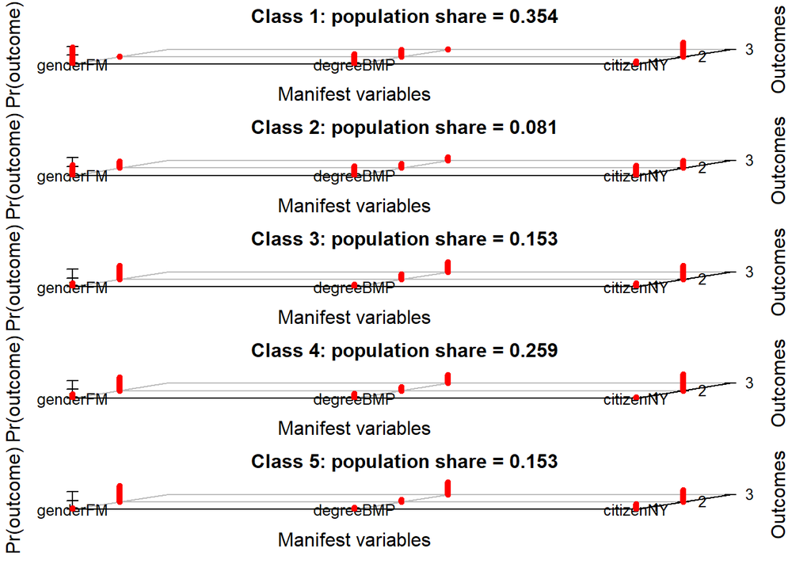

```r
plot(lca5Classes)
```

At the end of all this, we have several models that throw us an explicit warning about negative degrees of freedom (we should probably listen to such a warning). We have other variables that you could play with and discretize, but we could always do that another day. To that end, we should probably just stick with the 2 class model.

You might be thinking, “The classes really don’t seem to capture everybody that we could have”, and you would be correct on this one. However, looking at some tables might make this clear:

```r
table(week10$genderFM, week10$degreeBMP,
      week10$citizenNY, deparse.level =  2)
```

```
## , , week10$citizenNY = 1
##
##                week10$degreeBMP
## week10$genderFM   1   2   3
##               1  71  48  21
##               2  33  32  79
##
## , , week10$citizenNY = 2
##
##                week10$degreeBMP
## week10$genderFM   1   2   3
##               1 271 198  76
##               2 126 128 301
```

Grand scheme – there just are not too many non-citizens compared to citizens. Furthermore, there are relatively fewer women than men with doctoral degrees.